# Python数据处理

## 09. 图数据库

主讲人：丁平尖

## 图数据库概述

- 图数据库是一种用于存储和处理复杂网络数据的数据库系统。
- 使用图结构进行语义查询，节点、边和属性代表存储的数据
- 使用属性图模型：
  - 实体（节点）可以持有任意数量的属性（键值对），并且可以用标签（类型）标记，代表它们在您的领域中的不同角色
  - 关系提供两个节点实体之间的有向、命名连接。关系总是有方向的，有类型，有起始节点和结束节点
- 适合半结构化和高度连接的数据
- 需要一种新的查询语言

## 图数据库与关系数据库的比较

- 关系数据库
  - 以行和列的表格形式存储数据，遵循严格的关系模式（Schema）。数据通过外键（Foreign Key）连接在一起。适合存储结构化数据，遵循关系代数的操作。
  - 使用结构化查询语言（SQL）进行数据的查询和管理。查询的复杂度随着数据关系的增加而增加，尤其是涉及多表联接的情况。
  - 在数据量增加时，通常通过垂直扩展（Vertical Scaling）方式，即通过提升服务器性能来支持更大的数据存储和处理。但当数据规模增大到一定程度时，性能会受到限制。
  - 适合于数据关系较简单、需要事务性处理（如银行系统、库存管理）的应用场景。对事务处理和一致性要求高的系统更适合使用关系数据库。

## 图数据库与关系数据库的比较

- 图数据库
  - 使用节点（Nodes）、边（Edges）和属性（Properties）来表示和存储数据。节点代表实体，边表示实体之间的关系，适合用来表示高度连接的数据。图数据库中，数据的结构可以随时扩展，不需要预定义固定的模式。
  - 使用图查询语言，如Cypher（Neo4j）。图数据库非常适合快速执行多跳（multi-hop）查询，不需进行多表联接，查询效率更高。
  - 更适合水平扩展，能够方便地将数据分布到多个节点上，扩展性更强。因此在处理大型数据集，尤其是数据之间存在复杂关系时，图数据库更有优势。
  - 广泛用于社交网络、推荐系统、欺诈检测、供应链管理等场景，这些领域的数据之间具有复杂的关系。图数据库在图数据分析、路径发现和社交网络关系分析等方面具有独特优势。

## Neo4j图数据库

- Neo4j 主要通过节点（Nodes）、关系（Relationships）和属性（Properties）来存储和管理数据。
- Neo4j 使用 Cypher 语言进行数据的查询、更新和管理。Cypher 类似 SQL，但专为图数据库设计，具有简单、易读的图形化查询语法。
- Neo4j 支持 ACID（Atomicity、Consistency、Isolation、Durability）特性，确保数据的可靠性和一致性。
- Neo4j 支持水平和垂直扩展，虽然它原本是一个集中式数据库，但 Neo4j Enterprise Edition 允许在多节点集群上部署，支持更大规模的数据集。

## Cypher查询语言

- Cypher 是 Neo4j 专门设计的一种图数据库查询语言，用于查询、操作和管理图数据。它类似 SQL，但更适合图数据的查询操作，允许用户通过直观的语法定义复杂的关系查询。
- 图形化的查询语法
  - Cypher 语句的语法设计直接反映了图数据库的结构：节点用圆括号表示 ()，关系用方括号表示 []。
- Cypher 的设计目标之一是“人类可读性”，它用简洁的语法描述复杂的关系。
- Cypher 操作符合 ACID 特性，确保查询和数据操作具有原子性、一致性、隔离性和持久性。
- 开发者可以在不同平台上轻松调用 Cypher 语句，特别适合用于图数据库的集成开发和应用扩展。
- Cypher查询的结构
  - 节点被括号包围，看起来像圆圈，例如`(a)`
  - 关系基本上是两个节点之间的箭头`-`,`->`，在箭头内方括号`[]`中放置额外的信息

## Neo4j资源

- Neo4j网站：
  - https://neo4j.com/
  - 链接：https://pan.baidu.com/s/1CTvIETTgcCOgjJxw7sjXKQ?pwd=1111 提取码：1111
- Neo4j安装手册：
  - https://neo4j.com/docs/operationsmanual/current/deployment/single-instance/
- Cypher参考卡
  - https://neo4j.com/docs/cypher-refcard/current/

## Neo4j浏览器

- 打开URL http://localhost:7474（将“localhost”替换为您的服务器名称，将7474替换为neo4j.conf中设置的端口名称）
  - 也可以利用bolt打开（可以从Neo4J desktop打开）
- 输入用户名/密码（如果没有设置，Neo4j浏览器将提示您选择用户名和密码）
- 通过输入Cypher查询并观察结果开始使用Neo4j
- 将常用查询保存到收藏夹

## Neo4J

- https://neo4j.com/docs/getting-started/introduction/
- 在 Neo4j 中，信息以节点、关系和属性的形式组织。
  - 节点是图中的实体。
    - 节点可以标记标签，以表示它们在域中的不同角色（例如，Person）。
    - 节点可以拥有任意数量的键值对或属性（例如，name）。
  - 关系提供了两个节点实体之间的有方向、命名的连接（例如，Person LOVES Person）。
    - 关系始终具有方向、类型、起始节点和结束节点，并且可以像节点一样拥有属性。
    - 节点可以具有任意数量或类型的关系，而不会影响性能。

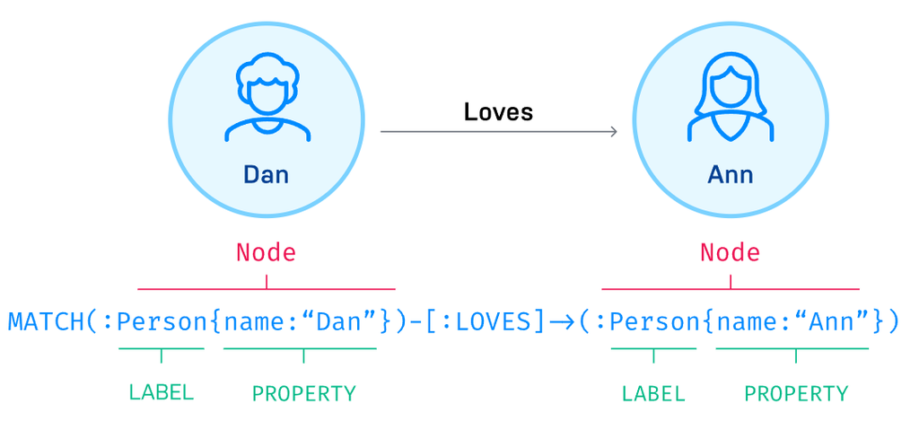

## Neo4j Python库

- Neo4j 提供了 Python 库，用于在 Python 应用程序中连接和操作 Neo4j 数据库。这个库封装了与 Neo4j 数据库的交互，使开发者能够在 Python 环境中使用 Cypher 查询来管理和分析图数据。
- 安装
  - pip install neo4j
- 步骤：
  - 连接数据库：使用 Neo4j 驱动程序的核心是 GraphDatabase 类，通过 GraphDatabase.driver 方法创建数据库连接。连接 Neo4j 时需要提供数据库的 URI、用户名和密码。
  - Session 对象用于管理会话，可以执行 Cypher 查询。
  - 使用 session.run() 可以执行 Cypher 查询。
  - 操作完成后需要关闭驱动程序连接，以确保资源被正确释放。

```python
# 连接数据库并建立会话对象
import warnings
warnings.filterwarnings('ignore')
from neo4j import GraphDatabase
# URI examples: "neo4j://localhost", "neo4j+s://xxx.databases.neo4j.io"
URI = "neo4j://localhost"
AUTH = ("neo4j", "12345678")

driver = GraphDatabase.driver(URI, auth=AUTH)

session = driver.session(database="example")
```

```python
session.run("MATCH (n) DETACH DELETE n")
def print_nodes():
    results = session.run("MATCH (n) RETURN *")
    for record in results:
        print(record.data())
def print_relationships():
    results = session.run("MATCH (n1)-[r]->(n2) RETURN n1, r, n2")
    for record in results:
        print(record.data())
```

## CREATE语句

- - `CREATE`子句允许您创建一个或多个节点。每个节点都可以分配标签和属性。您可以将每个节点绑定到一个变量，以便稍后在查询中引用该变量。多个标签用冒号分隔。

```python
session.run("CREATE (charlie:Person:Actor {name: 'Charlie Sheen'}), (oliver:Person:Director {name: 'Oliver Stone'})")
```

```
<neo4j._sync.work.result.Result at 0x2acff056d90>
```

[figure not shown]

- 关系也可以使用CREATE语句创建。与节点不同，关系始终只需要一种关系类型和一个方向。与节点类似，关系可以分配属性和关系类型，并绑定到变量。

```python
session.run("""CREATE (charlie:Person:Actor {name: 'Charlie Sheen'})-[:ACTED_IN {role: 'Bud Fox'}]
        ->(wallStreet:Movie {title: 'Wall Street'})<-
        [:DIRECTED]-(oliver:Person:Director {name: 'Oliver Stone'})""")
```

```
<neo4j._sync.work.result.Result at 0x2ac82764690>
```

[figure not shown]

## MATCH语句

- MATCH子句可以指定模式中的节点、关系和属性，从而允许遍历图形的查询来检索相关数据。

```python
# 查找图中所有节点
results = session.run("MATCH (n) RETURN n")
for record in results:
    print(record.data())
```

```
{'n': {'title': 'Wall Street'}}
{'n': {'name': 'Oliver Stone'}}
{'n': {'name': 'Charlie Sheen'}}
{'n': {'name': 'Oliver Stone'}}
{'n': {'name': 'Charlie Sheen'}}
```

```python
# 查找具有特定标签的节点
results = session.run("MATCH (movie:Movie) RETURN movie")
results.data()
```

```
[{'movie': {'title': 'Wall Street'}}]
```

- 上例在指定节点之间创建了一条路径。请注意，这些新创建的节点和关系与图中先前的内容无关。要将它们连接到现有数据，请将所需的节点和关系绑定到变量。然后，这些变量可以传递给查询中针对图中现有元素的后续子句。

```python
session.run("MATCH (n) DETACH DELETE n")
session.run("CREATE (charlie:Person:Actor {name: 'Charlie Sheen'}), (oliver:Person:Director {name: 'Oliver Stone'})")
session.run("""MATCH (charlie:Person {name: 'Charlie Sheen'}), (oliver:Person {name: 'Oliver Stone'})
CREATE (charlie)-[:ACTED_IN {role: 'Bud Fox'}]->(wallStreet:Movie {title: 'Wall Street'})<-[:DIRECTED]-(oliver)""")
```

```
<neo4j._sync.work.result.Result at 0x2ac82744090>
```

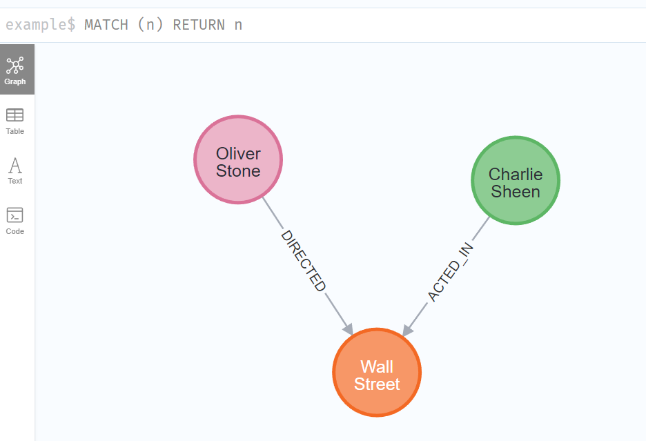

## DELETE语句

- 该DELETE子句用于删除节点、关系或路径。

```python
# 删除所有节点
session.run("MATCH (n) DETACH DELETE n")
```

```
<neo4j._sync.work.result.Result at 0x2ac827a8990>
```

```python
# 先创建一些节点和边
session.run("""CREATE
  (keanu:Person {name: 'Keanu Reever'}),
  (laurence:Person {name: 'Laurence Fishburne'}),
  (carrie:Person {name: 'Carrie-Anne Moss'}),
  (tom:Person {name: 'Tom Hanks'}),
  (theMatrix:Movie {title: 'The Matrix'}),
  (keanu)-[:ACTED_IN]->(theMatrix),
  (laurence)-[:ACTED_IN]->(theMatrix),
  (carrie)-[:ACTED_IN]->(theMatrix)""")
```

```
<neo4j._sync.work.result.Result at 0x2acff0eec90>
```

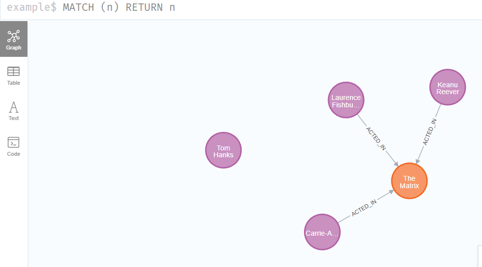

```python
# 删除单个节点
results = session.run("""MATCH (n) RETURN n""")
for record in results:
    print(record.data())
session.run("""MATCH (n:Person {name: 'Tom Hanks'}) DELETE n""")
print("********************************")
results = session.run("""MATCH (n) RETURN n""")
for record in results:
    print(record.data())
```

```
{'n': {'title': 'The Matrix'}}
{'n': {'name': 'Keanu Reever'}}
{'n': {'name': 'Laurence Fishburne'}}
{'n': {'name': 'Carrie-Anne Moss'}}
{'n': {'name': 'Tom Hanks'}}
{'n': {'title': 'The Matrix'}}
{'n': {'name': 'Keanu Reever'}}
{'n': {'name': 'Laurence Fishburne'}}
{'n': {'name': 'Carrie-Anne Moss'}}
```

```python
# 可以删除某种关系，但与该关系相连的节点不受影响。
results = session.run("MATCH (a)-[r:ACTED_IN]->(b) RETURN a, r, b")
for record in results:
    print(record.data())
print("***************************************************")
session.run("""MATCH (n:Person {name: 'Laurence Fishburne'})-[r:ACTED_IN]->() DELETE r""")
results = session.run("MATCH (a)-[r:ACTED_IN]->(b) RETURN a, r, b")
for record in results:
    print(record.data())
```

```
{'a': {'name': 'Keanu Reever'}, 'r': ({'name': 'Keanu Reever'}, 'ACTED_IN', {'title': 'The Matrix'}), 'b': {'title': 'The Matrix'}}
{'a': {'name': 'Laurence Fishburne'}, 'r': ({'name': 'Laurence Fishburne'}, 'ACTED_IN', {'title': 'The Matrix'}), 'b': {'title': 'The Matrix'}}
{'a': {'name': 'Carrie-Anne Moss'}, 'r': ({'name': 'Carrie-Anne Moss'}, 'ACTED_IN', {'title': 'The Matrix'}), 'b': {'title': 'The Matrix'}}
{'a': {'name': 'Keanu Reever'}, 'r': ({'name': 'Keanu Reever'}, 'ACTED_IN', {'title': 'The Matrix'}), 'b': {'title': 'The Matrix'}}
{'a': {'name': 'Carrie-Anne Moss'}, 'r': ({'name': 'Carrie-Anne Moss'}, 'ACTED_IN', {'title': 'The Matrix'}), 'b': {'title': 'The Matrix'}}
```

```python
session.run("""MATCH (n:Person {name: 'Carrie-Anne Moss'})
                DELETE n""")
```

[output not shown]

[output cut: 9 more lines]

[output not shown]

```python
# 要删除节点及其连接的任何关系，请使用该DETACH DELETE子句
results = session.run("MATCH (a)-[r:ACTED_IN]->(b) RETURN a, r, b")
for record in results:
    print(record.data())
print("*****************************************************")
session.run("""MATCH (n:Person {name: 'Carrie-Anne Moss'})
                DETACH DELETE n""")
results = session.run("MATCH (a)-[r:ACTED_IN]->(b) RETURN a, r, b")
for record in results:
    print(record.data())
```

```
{'a': {'name': 'Keanu Reever'}, 'r': ({'name': 'Keanu Reever'}, 'ACTED_IN', {'title': 'The Matrix'}), 'b': {'title': 'The Matrix'}}
{'a': {'name': 'Carrie-Anne Moss'}, 'r': ({'name': 'Carrie-Anne Moss'}, 'ACTED_IN', {'title': 'The Matrix'}), 'b': {'title': 'The Matrix'}}
{'a': {'name': 'Keanu Reever'}, 'r': ({'name': 'Keanu Reever'}, 'ACTED_IN', {'title': 'The Matrix'}), 'b': {'title': 'The Matrix'}}
```

## MERGE语句

- 该MERGE子句要么匹配图形中现有的节点模式并绑定它们，要么在不存在的情况下创建新数据并绑定它。这样，它就充当了和的组合MATCH，CREATE可以根据指定的数据是匹配还是创建来执行特定操作。

```python
print_nodes()
session.run("""MERGE (robert:Critic {name: "Robert"})
    RETURN robert""")
print("*********************************")
print_nodes()
```

```
{'n': {'title': 'The Matrix'}}
{'n': {'name': 'Keanu Reever'}}
{'n': {'name': 'Laurence Fishburne'}}
{'n': {'title': 'The Matrix'}}
{'n': {'name': 'Robert'}}
{'n': {'name': 'Keanu Reever'}}
{'n': {'name': 'Laurence Fishburne'}}
```

```python
print_nodes()
session.run("""MERGE (robert:Critic {name: "Robert"})
    RETURN robert""")
print("*********************************")
print_nodes()
```

```
{'n': {'title': 'The Matrix'}}
{'n': {'name': 'Robert'}}
{'n': {'name': 'Keanu Reever'}}
{'n': {'name': 'Laurence Fishburne'}}
{'n': {'title': 'The Matrix'}}
{'n': {'name': 'Robert'}}
{'n': {'name': 'Keanu Reever'}}
{'n': {'name': 'Laurence Fishburne'}}
```

## SET语句

- SET子句用于更新节点上的标签以及节点和关系上的属性

```python
session.run("MATCH (n) DETACH DELETE n")
session.run("CREATE (n:Swedish {name: 'Andy'}), (m:German {name: 'Sara'})")
print_nodes()
```

```
{'n': {'name': 'Andy'}}
{'n': {'name': 'Sara'}}
```

```python
results = session.run("""MATCH (n {name: 'Andy'})
            SET n.surname = 'Taylor'
            RETURN n.name, n.surname""")
results.data()
```

```
[{'n.name': 'Andy', 'n.surname': 'Taylor'}]
```

```python
session.run("""MATCH(n {name: 'Andy'}), (m:German {name: 'Sara'})
            CREATE (n)-[r:KNOWS]->(m)""")
```

```
<neo4j._sync.work.result.Result at 0x21b50ebd9d0>
```

```python
results = session.run("""MATCH (n:Swedish {name: 'Andy'})-[r:KNOWS]->(m:German {name: 'Sara'})
                        SET r.since = 1999
                        RETURN n, r, m, r.since""")
results.data()
```

```
[{'n': {'surname': 'Taylor', 'name': 'Andy'},
  'r': ({'surname': 'Taylor', 'name': 'Andy'}, 'KNOWS', {'name': 'Sara'}),
  'm': {'name': 'Sara'},
  'r.since': 1999}]
```

## REMOVE语句

- 该REMOVE子句用于从节点和关系中删除属性，并从节点中删除标签。

```python
session.run("MATCH (n) DETACH DELETE n")
session.run("""CREATE
  (a:Swedish {name: 'Andy', age: 36, propTestValue1: 42}),
  (t:Swedish {name: 'Timothy', age: 25, propTestValue2: 42}),
  (p:German:Swedish {name: 'Peter', age: 34}),
  (a)-[:KNOWS]->(t),
  (a)-[:KNOWS]->(p)""")
results = session.run("MATCH (n) RETURN n, labels(n)")
results.data()
```

```
[{'n': {'propTestValue1': 42, 'name': 'Andy', 'age': 36},
  'labels(n)': ['Swedish']},
 {'n': {'propTestValue2': 42, 'name': 'Timothy', 'age': 25},
  'labels(n)': ['Swedish']},
 {'n': {'name': 'Peter', 'age': 34}, 'labels(n)': ['Swedish', 'German']}]
```

```python
results = session.run("""MATCH (a {name: 'Andy'})
                REMOVE a.age
                 RETURN a.name, a.age""")
results.data()
```

```
[{'a.name': 'Andy', 'a.age': None}]
```

## ORDER BY语句

```python
results = session.run("""MATCH (n)
                RETURN n.name, n.age
                ORDER BY n.name ASC""")
results.data()
```

```
[{'n.name': 'Andy', 'n.age': None},
 {'n.name': 'Peter', 'n.age': 34},
 {'n.name': 'Timothy', 'n.age': 25}]
```

## FOREACH函数

- FOREACH用于对集合中的每个元素执行某个操作。它非常适合在创建节点或关系时进行批量处理。

```python
session.run("MATCH (n) DETACH DELETE n")
session.run("""WITH ["Alice", "Bob", "Charlie"] AS names
        FOREACH (name IN names | CREATE (n:Person {name: name}))""")
print_nodes()
```

```
{'n': {'name': 'Bob'}}
{'n': {'name': 'Charlie'}}
{'n': {'name': 'Alice'}}
```

```python
session.close()
driver.close()
```

## neomodel

- Neomodel 是 Neo4j 的一个 Python ORM（对象关系映射）库，使得在 Python 中使用对象的方式操作图数据库变得更加简便。
- Neomodel 通过面向对象的结构封装了 Cypher 查询语句，简化了 Neo4j 数据库的使用，适合数据科学、机器学习项目中的图数据处理和知识图谱构建。
- https://neomodel.readthedocs.io/en/latest/getting_started.html
- 安装：
  - pip install neomodel

```python
from neomodel import (config, StructuredNode, StringProperty, IntegerProperty,
    UniqueIdProperty, RelationshipTo)
config.DATABASE_URL = "bolt://neo4j:12345678@localhost:7687/neomodelexample"
```

```python
class Country(StructuredNode):
    code = StringProperty(unique_index=True, required=True)

class City(StructuredNode):
    name = StringProperty(required=True)
    country = RelationshipTo(Country, 'FROM_COUNTRY')

class Person(StructuredNode):
    uid = UniqueIdProperty()
    name = StringProperty(unique_index=True)
    age = IntegerProperty(index=True, default=0)

    # traverse outgoing IS_FROM relations, inflate to Country objects
    country = RelationshipTo(Country, 'IS_FROM')

    # traverse outgoing LIVES_IN relations, inflate to City objects
    city = RelationshipTo(City, 'LIVES_IN')
```

```python
from neomodel import db
db.cypher_query("MATCH (n) DETACH DELETE n")
# 创建节点
jim = Person(name='Jim', age=3).save() # Create
print(jim)
print(jim.age)
```

```
{'uid': '291b4d8e74e24ee9885137194964ff0a', 'name': 'Jim', 'age': 3, 'element_id_property': '4:44efcb72-4d1d-4a85-a35c-4a09712f17bd:1'}
3
```

```python
# 更新节点
jim.age = 5
jim.save() # Update, (with validation)
jim.age
```

```
5
```

```python
# 查询所有节点
Person(name='Bob', age=5).save()
all_nodes = Person.nodes.all()
print(all_nodes)
```

```
[<Person: {'uid': '291b4d8e74e24ee9885137194964ff0a', 'name': 'Jim', 'age': 5, 'element_id_property': '4:44efcb72-4d1d-4a85-a35c-4a09712f17bd:1'}>, <Person: {'uid': 'caf2c5a9c90043dab63fdde91600cab3', 'name': 'Bob', 'age': 5, 'element_id_property': '4:44efcb72-4d1d-4a85-a35c-4a09712f17bd:2'}>]
```

```python
# 通过特定属性查找节点
jim = Person.nodes.get(name='Jim')
jim
```

```
<Person: {'uid': '291b4d8e74e24ee9885137194964ff0a', 'name': 'Jim', 'age': 5, 'element_id_property': '4:44efcb72-4d1d-4a85-a35c-4a09712f17bd:1'}>
```

```python
# 创建关系
germany = Country(code='DE').save()
jim.country.connect(germany)
jim.country.all()
```

```
[<Country: {'code': 'DE', 'element_id_property': '4:44efcb72-4d1d-4a85-a35c-4a09712f17bd:0'}>]
```

```python
# 删除关系
jim.country.disconnect(germany)
jim.country.all()
```

```
[]
```